# Path analysis: NCP → Biogeochemistry → Coral physiology

- Show All Code
- Hide All Code
- View Source

Material Legacies / Indirect Effects — *Limnology and Oceanography* Revision

Published

April 30, 2026

## Overview

This document presents a tank-level path analysis testing the proposed causal chain:

```
NCP → pH, DOC
pH + DOC → Chlorophyll-a → Endosymbiont density, GP, R, Tissue biomass
```

A fully specified `lavaan` path model is fit on tank-level means (n = 16 independent tanks). Path coefficients are labeled so that **indirect (mediated) effects** can be computed via the delta method, quantifying how much of the NCP signal propagates through to coral physiology at each step of the chain.

# Setup

```r
library(tidyverse)
library(here)
library(lavaan)
library(kableExtra)
library(seacarb)
library(broom)
library(lubridate)
library(lme4)
library(lmerTest)
library(emmeans)
library(patchwork)
```

# Data loading

```r
metadata <- read_csv(here("Data", "MO24BEAST_Metadata_FULL.csv")) |>
  mutate(
    TREATMENT = factor(TREATMENT,
                       levels = c("Control", "Algae_Dom", "Coral_Dom", "Rubble_Dom")),
    mean_tissue_biomass = ifelse(mean_tissue_biomass > 30, NA, mean_tissue_biomass)
  )
```

```r
pHcalib  <- read_csv(here("Data", "Chemistry", "TrisCalSummer2024.csv"))
pHData   <- read_csv(here("Data", "Chemistry", "CarbonateChemistry.csv"))
TableID  <- read_csv(here("Data", "TableID.csv"))
DOC_data <- read_csv(here("Data", "DOC", "DOC_full_data.csv"))

pHSlope <- pHcalib |>
  nest_by(TrisCalDate) |>
  mutate(fitpH = list(lm(mVTris ~ TTris, data = pHcalib))) |>
  reframe(broom::tidy(fitpH)) |>
  select(TrisCalDate, term, estimate) |>
  pivot_wider(names_from = term, values_from = estimate) |>
  right_join(pHData, by = "TrisCalDate") |>
  mutate(mVTris = TEMPINLAB * TTris + `(Intercept)`) |>
  drop_na(TEMPINSITU, mV) |>
  mutate(pH = pH(Ex = mV, Etris = mVTris, S = SALINITY, T = TEMPINLAB)) |>
  drop_na(TEMPINSITU, TEMPINLAB, SALINITY, pH) |>
  mutate(pH_insitu = pHinsi(
    pH = pH, ALK = 2200, Tinsi = TEMPINSITU, Tlab = TEMPINLAB,
    S = SALINITY, Pt = 0.1, k1k2 = "m10", kf = "dg"
  )) |>
  select(-pH) |> rename(pH = pH_insitu) |>
  ungroup() |>
  select(-c(mV, TrisCalDate, TTris, `(Intercept)`, mVTris))

DIC_calc <- pHSlope |>
  drop_na(pH, TA) |>
  mutate(TA_mol_kg = TA / 1e6)

carb_table <- carb(
  flag = 8, var1 = DIC_calc$pH, var2 = DIC_calc$TA_mol_kg,
  S = DIC_calc$SALINITY, T = DIC_calc$TEMPINSITU,
  P = 0, Patm = 0, Pt = 0, Sit = 0,
  pHscale = "T", kf = "dg", k1k2 = "m10", ks = "d"
)

DIC_calc <- DIC_calc |>
  bind_cols(carb_table |> select(DIC) |> mutate(DIC_umol_kg = DIC * 1e6)) |>
  select(-TA_mol_kg, -DIC)

pHSlope2 <- pHSlope |>
  left_join(DIC_calc |> select(any_of(names(pHSlope)), DIC_umol_kg),
            by = intersect(names(pHSlope), names(DIC_calc))) |>
  mutate(TREATMENT = ifelse(is.na(TREATMENT), "Inflow", TREATMENT)) |>
  full_join(DOC_data |> select(-DATETIME),
            by = intersect(names(pHSlope), names(DOC_data))) |>
  select(-c(NPOC_mg_L, TN_mg_L))

InflowData <- pHSlope2 |>
  filter(TANK_NUM %in% c("Inflow1", "Inflow2")) |>
  select(-c(FLOW_LEFT, FLOW_RIGHT, Notes, DO_MG_L, SALINITY, TEMPINSITU)) |>
  rename(pH_inflow = pH, TA_inflow = TA,
         DIC_inflow = DIC_umol_kg, DOC_inflow = NPOC_uM) |>
  mutate(INFLOW_TABLE = ifelse(TANK_NUM == "Inflow1", 1, 2)) |>
  ungroup() |>
  select(DATE, TIME, INFLOW_TABLE, pH_inflow, TA_inflow, DIC_inflow, DOC_inflow)

SurfaceArea <- 22.5 * 22.5

Data <- pHSlope2 |>
  ungroup() |>
  filter(!TANK_NUM %in% c("Inflow1", "Inflow2")) |>
  mutate(TANK_NUM = as.numeric(TANK_NUM)) |>
  left_join(TableID |> select(TANK_NUM, INFLOW_TABLE), by = "TANK_NUM") |>
  left_join(InflowData, by = c("DATE", "TIME", "INFLOW_TABLE")) |>
  mutate(
    DATETIME       = ymd_hms(paste(DATE, TIME)),
    deltapH        = pH - pH_inflow,
    deltaDOC       = NPOC_uM - DOC_inflow,
    totalflow      = FLOW_RIGHT + FLOW_LEFT,
    residence_time = (1 / totalflow) * (10000 / 60),
    flowrate       = totalflow / 60,
    deltaTA        = TA_inflow - TA,
    deltaDIC       = DIC_inflow - DIC_umol_kg,
    NEC = (deltaTA / 2) * 1.025 * 10 * (1 / residence_time) * (1 / SurfaceArea),
    NEP = (deltaDIC * 1.025 * 10 * (1 / residence_time) * (1 / SurfaceArea)) - NEC
  )

treatment_levels <- c("Control", "Algae_Dom", "Coral_Dom", "Rubble_Dom")

chem_reframe_DAY_clean <- Data |>
  filter(TIME == hms::as_hms("12:00:00")) |>
  group_by(TREATMENT, DATE, TANK_NUM) |>
  select(DATE, TIME, TANK_NUM, TREATMENT,
         TA, pH, DIC_umol_kg, NPOC_uM, deltapH, deltaTA, deltaDOC, deltaDIC, NEC, NEP) |>
  rename(DOC = NPOC_uM) |>
  mutate(
    deltaDIC    = ifelse(deltaDIC < -250,   NA, deltaDIC),
    deltaDOC    = ifelse(deltaDOC > 200,    NA, deltaDOC),
    deltaTA     = ifelse(deltaTA < -400,    NA, deltaTA),
    DIC_umol_kg = ifelse(DIC_umol_kg > 2250, NA, DIC_umol_kg),
    DOC         = ifelse(DOC > 350,         NA, DOC),
    NEC         = ifelse(NEC < -2,          NA, NEC),
    NEC         = ifelse(TREATMENT == "Rubble_Dom" & NEC > 2, NA, NEC),
    NEP         = ifelse(NEP < -2.1,        NA, NEP),
    NEP         = ifelse(NEP > 5,           NA, NEP),
    pH          = ifelse(pH < 7.8,          NA, pH),
    TA          = ifelse(TA > 2700,         NA, TA)
  )

chem_reframe_NIGHT_clean <- Data |>
  filter(TIME == hms::as_hms("21:00:00")) |>
  group_by(TREATMENT, DATE, TANK_NUM) |>
  select(DATE, TIME, TANK_NUM, TREATMENT,
         TA, pH, DIC_umol_kg, NPOC_uM, deltaTA, deltaDIC, NEC, NEP) |>
  rename(DOC = NPOC_uM) |>
  mutate(
    DIC_umol_kg = ifelse(DIC_umol_kg < 1900, NA, DIC_umol_kg),
    DOC         = ifelse(DOC > 400,          NA, DOC),
    NEC         = ifelse(NEC > 1,            NA, NEC),
    NEC         = ifelse(NEC < -1,           NA, NEC),
    NEP         = ifelse(NEP > 2,            NA, NEP),
    NEP         = ifelse(TREATMENT == "Control" & NEP > 1, NA, NEP),
    TA          = ifelse(TA < 2250,          NA, TA)
  )
```

# Biogeochemical differences by treatment

Before testing the mediation pathway, we first ask whether the four community treatments produced measurable differences in NCP, NCC, pH, and DOC. Measurements are examined separately at **noon (12:00)** and **9 PM (21:00)** to distinguish daytime production and calcification signals from nighttime respiration dynamics. Mixed-effects models include tank identity as a random intercept to account for repeated daily measurements on the same tank (`response ~ TREATMENT + (1 | TANK_NUM)`).

## Figure

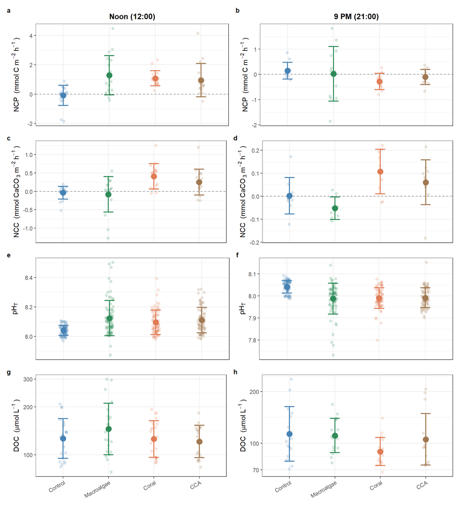

Figure 1: Biogeochemical variables by community treatment at noon (left column) and 9 PM (right column). Small points are individual daily measurements; large points are treatment means; error bars are ±1 SD. Dashed line at zero for NCP and NCC.

```r
trt_colors <- c("Control" = "#4682B4", "Algae_Dom" = "#2E8B57",
                "Coral_Dom" = "#E07B54", "Rubble_Dom" = "#A07850")
trt_labels <- c("Control" = "Control", "Algae_Dom" = "Macroalgae",
                "Coral_Dom" = "Coral",  "Rubble_Dom" = "CCA")

chem_plot_day   <- chem_reframe_DAY_clean   |> ungroup() |>
  mutate(TREATMENT = factor(TREATMENT, levels = treatment_levels))
chem_plot_night <- chem_reframe_NIGHT_clean |> ungroup() |>
  mutate(TREATMENT = factor(TREATMENT, levels = treatment_levels))

make_trt_panel <- function(df, var, ylab, hline = FALSE,
                           col_title = NULL, show_x = FALSE) {
  p <- ggplot(df, aes(x = TREATMENT, y = .data[[var]], color = TREATMENT)) +
    { if (hline) geom_hline(yintercept = 0, lty = 2, color = "grey50") } +
    geom_point(size = 1.8, alpha = 0.2,
               position = position_jitter(width = 0.08, seed = 7)) +
    stat_summary(fun.data = mean_sdl, geom = "errorbar",
                 fun.args = list(mult = 1), width = 0.22, linewidth = 0.8) +
    stat_summary(fun = mean, geom = "point", size = 4) +
    scale_x_discrete(labels = trt_labels) +
    scale_color_manual(values = trt_colors) +
    labs(x = NULL, y = ylab, title = col_title) +
    theme_bw(base_size = 11) +
    theme(legend.position = "none",
          plot.title = element_text(hjust = 0.5, face = "bold", size = 12))
  if (show_x) {
    p + theme(axis.text.x = element_text(angle = 30, hjust = 1))
  } else {
    p + theme(axis.text.x = element_blank(), axis.ticks.x = element_blank())
  }
}

ncp_lab <- expression("NCP  (mmol C m"^-2~h^-1~")")
ncc_lab <- expression("NCC  (mmol CaCO"[3]~m^-2~h^-1~")")
ph_lab  <- expression("pH"[T])
doc_lab <- expression("DOC  ("*mu*mol~L^-1~")")

# Noon column
pd_ncp <- make_trt_panel(chem_plot_day,   "NEP", ncp_lab, hline=TRUE,  col_title="Noon (12:00)")
pd_ncc <- make_trt_panel(chem_plot_day,   "NEC", ncc_lab, hline=TRUE)
pd_ph  <- make_trt_panel(chem_plot_day,   "pH",  ph_lab)
pd_doc <- make_trt_panel(chem_plot_day,   "DOC", doc_lab, show_x=TRUE) + scale_y_log10()

# 9 PM column
pn_ncp <- make_trt_panel(chem_plot_night, "NEP", ncp_lab, hline=TRUE,  col_title="9 PM (21:00)")
pn_ncc <- make_trt_panel(chem_plot_night, "NEC", ncc_lab, hline=TRUE)
pn_ph  <- make_trt_panel(chem_plot_night, "pH",  ph_lab)
pn_doc <- make_trt_panel(chem_plot_night, "DOC", doc_lab, show_x=TRUE) + scale_y_log10()

(pd_ncp | pn_ncp) /
(pd_ncc | pn_ncc) /
(pd_ph  | pn_ph)  /
(pd_doc | pn_doc) +
  plot_annotation(tag_levels = "a") &
  theme(plot.tag = element_text(size = 10, face = "bold"))
```

## Mixed-effects models

```r
prep_model_data <- function(df) {
  df |> ungroup() |>
    mutate(TREATMENT = factor(TREATMENT, levels = treatment_levels),
           TANK_NUM  = factor(TANK_NUM))
}

model_data_day   <- prep_model_data(chem_reframe_DAY_clean)
model_data_night <- prep_model_data(chem_reframe_NIGHT_clean)

fit_models <- function(df) {
  list(
    NCP = lmer(NEP ~ TREATMENT + (1 | TANK_NUM), data = df, REML = TRUE),
    NCC = lmer(NEC ~ TREATMENT + (1 | TANK_NUM), data = df, REML = TRUE),
    pH  = lmer(pH  ~ TREATMENT + (1 | TANK_NUM), data = df, REML = TRUE),
    DOC = lmer(log(DOC) ~ TREATMENT + (1 | TANK_NUM), data = df, REML = TRUE)
  )
}

mods_day   <- fit_models(model_data_day)
mods_night <- fit_models(model_data_night)

build_f_table <- function(mods, time_label) {
  map2(mods, names(mods),
       ~anova(.x) |> as.data.frame() |> mutate(Variable = .y, Time = time_label)) |>
    bind_rows() |>
    select(Time, Variable, NumDF, DenDF, `F value`, `Pr(>F)`) |>
    mutate(across(where(is.numeric), ~round(.x, 4)))
}

f_table <- bind_rows(
  build_f_table(mods_day,   "Noon"),
  build_f_table(mods_night, "9 PM")
)

f_table |>
  kbl(
    caption = "Treatment effects at noon and 9 PM (Type III Satterthwaite F-tests). Green = p < 0.05; yellow = 0.05 ≤ p < 0.10.",
    col.names = c("Time", "Variable", "df (num.)", "df (den.)", "F", "p")
  ) |>
  kable_styling(bootstrap_options = c("striped", "condensed"), full_width = FALSE) |>
  collapse_rows(columns = 1, valign = "top") |>
  row_spec(which(f_table$`Pr(>F)` <  0.05), background = "#d4edda") |>
  row_spec(which(f_table$`Pr(>F)` >= 0.05 & f_table$`Pr(>F)` < 0.10),
           background = "#fff3cd")
```

Treatment effects at noon and 9 PM (Type III Satterthwaite F-tests). Green = p < 0.05; yellow = 0.05 ≤ p < 0.10.

|  | Time | Variable | df (num.) | df (den.) | F | p |
| --- | --- | --- | --- | --- | --- | --- |
| TREATMENT...1 | Noon | NCP | 3 | 66.0000 | 7.3365 | 0.0003 |
|  | Noon | NCC | 3 | 64.0000 | 7.4605 | 0.0002 |
|  | Noon | pH | 3 | 299.0000 | 13.9047 | 0.0000 |
|  | Noon | DOC | 3 | 84.0000 | 1.6004 | 0.1954 |
| TREATMENT...5 | 9 PM | NCP | 3 | 42.0000 | 0.9740 | 0.4140 |
|  | 9 PM | NCC | 3 | 12.0180 | 4.3704 | 0.0268 |
|  | 9 PM | pH | 3 | 11.9714 | 17.6179 | 0.0001 |
|  | 9 PM | DOC | 3 | 10.3268 | 1.4226 | 0.2917 |

### Noon — pairwise contrasts

```r
emm_day <- map2(
  mods_day, names(mods_day),
  ~emmeans(.x, pairwise ~ TREATMENT, adjust = "Tukey")$contrasts |>
    as.data.frame() |> mutate(Variable = .y)
) |>
  bind_rows() |>
  select(Variable, contrast, estimate, SE, df, t.ratio, p.value) |>
  mutate(across(where(is.numeric), ~round(.x, 4)))

emm_day |>
  kbl(
    caption = "Noon: pairwise Tukey contrasts. Green = p < 0.05; yellow = 0.05 ≤ p < 0.10.",
    col.names = c("Variable", "Contrast", "Estimate", "SE", "df", "t", "p (adj.)")
  ) |>
  kable_styling(bootstrap_options = c("striped", "condensed"), full_width = FALSE) |>
  collapse_rows(columns = 1, valign = "top") |>
  row_spec(which(emm_day$p.value <  0.05), background = "#d4edda") |>
  row_spec(which(emm_day$p.value >= 0.05 & emm_day$p.value < 0.10),
           background = "#fff3cd")
```

Noon: pairwise Tukey contrasts. Green = p < 0.05; yellow = 0.05 ≤ p < 0.10.

| Variable | Contrast | Estimate | SE | df | t | p (adj.) |
| --- | --- | --- | --- | --- | --- | --- |
| NCP | Control - Algae_Dom | -1.3749 | 0.3213 | 10.5704 | -4.2798 | 0.0066 |
|  | Control - Coral_Dom | -1.1673 | 0.3260 | 11.2466 | -3.5805 | 0.0187 |
|  | Control - Rubble_Dom | -1.0345 | 0.3309 | 12.1268 | -3.1258 | 0.0377 |
|  | Algae_Dom - Coral_Dom | 0.2077 | 0.3304 | 11.7991 | 0.6285 | 0.9208 |
|  | Algae_Dom - Rubble_Dom | 0.3404 | 0.3353 | 12.6967 | 1.0155 | 0.7436 |
|  | Coral_Dom - Rubble_Dom | 0.1328 | 0.3398 | 13.4271 | 0.3908 | 0.9789 |
| NCC | Control - Algae_Dom | 0.0427 | 0.1200 | 10.8115 | 0.3555 | 0.9838 |
|  | Control - Coral_Dom | -0.4446 | 0.1197 | 11.1119 | -3.7131 | 0.0152 |
|  | Control - Rubble_Dom | -0.2874 | 0.1215 | 11.9628 | -2.3654 | 0.1376 |
|  | Algae_Dom - Coral_Dom | -0.4872 | 0.1217 | 11.4645 | -4.0046 | 0.0089 |
|  | Algae_Dom - Rubble_Dom | -0.3300 | 0.1234 | 12.3165 | -2.6745 | 0.0814 |
|  | Coral_Dom - Rubble_Dom | 0.1572 | 0.1231 | 12.6558 | 1.2767 | 0.5928 |
| pH | Control - Algae_Dom | -0.0839 | 0.0139 | 11.9216 | -6.0205 | 0.0003 |
|  | Control - Coral_Dom | -0.0551 | 0.0139 | 11.9216 | -3.9549 | 0.0090 |
|  | Control - Rubble_Dom | -0.0700 | 0.0140 | 12.0746 | -5.0054 | 0.0015 |
|  | Algae_Dom - Coral_Dom | 0.0288 | 0.0139 | 11.9216 | 2.0656 | 0.2192 |
|  | Algae_Dom - Rubble_Dom | 0.0139 | 0.0140 | 12.0746 | 0.9949 | 0.7551 |
|  | Coral_Dom - Rubble_Dom | -0.0149 | 0.0140 | 12.0746 | -1.0638 | 0.7168 |
| DOC | Control - Algae_Dom | -0.1373 | 0.0893 | 11.8215 | -1.5367 | 0.4479 |
|  | Control - Coral_Dom | 0.0096 | 0.0883 | 11.3413 | 0.1089 | 0.9995 |
|  | Control - Rubble_Dom | 0.0450 | 0.0905 | 12.1884 | 0.4969 | 0.9583 |
|  | Algae_Dom - Coral_Dom | 0.1469 | 0.0883 | 11.3413 | 1.6630 | 0.3851 |
|  | Algae_Dom - Rubble_Dom | 0.1823 | 0.0905 | 12.1884 | 2.0139 | 0.2356 |
|  | Coral_Dom - Rubble_Dom | 0.0353 | 0.0895 | 11.7063 | 0.3949 | 0.9781 |